# act_report

## Insights & Visualizations

```python
# import pandas
import pandas as pd
```

```python
# load the database
full = pd.read_csv('twitter_full_database.csv')
```

#### Question #1: What is the percentage of dogs who received ratings that are lower than 10?

```python
# Find this percentage
len(full[full['rating_numerator'] < 10]) / len(full)
```

```
0.1984244214672575
```

**Answer**: Only 19,84% of all the dogs have received rating that are lower than 10.

#### Question #2: What are the respective shares of tweeting sources (Web, TweetDeck, iPhone, Vine)?

```python
# group the data frame by count of source type
source = full.groupby(['source'])['tweet_id'].count()
source
```

```
source
TweetDeck      11
Vine           90
Web            31
iPhone       1899
Name: tweet_id, dtype: int64
```

```python
# import matplotlib library
import matplotlib.pyplot as plt
%matplotlib inline
```

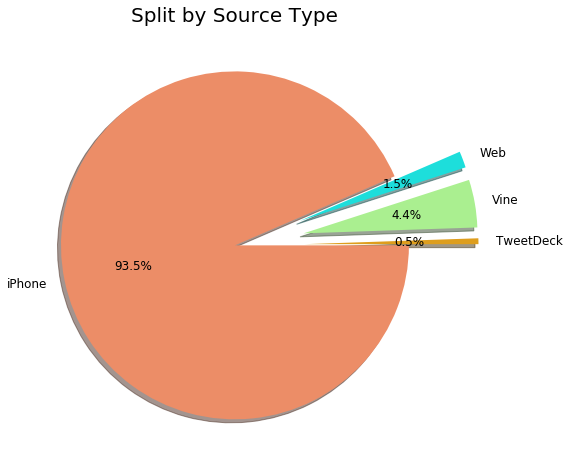

```python
# Build a pie chart
source.T.plot.pie(subplots=True,shadow=True,figsize=(8,8),fontsize=12, explode=(0.4,0.4,0.4,0),
                              colors = ['#DE9E1D','#AAEF90','#1DDEDB','#EC8D67'],autopct='%1.1f%%',startangle=0)
plt.title('Split by Source Type', fontsize=20)
plt.ylabel('')
```

Answer: Judging by this dataframe, the most popular tool to tweet via the account "We Rate Dogs" is **iPhone** - which is used **93.5%** of the time.

- the application Vine was used 4.4% of the time;
- the Twitter website was used in 1.5% of tweets;
- the least popular tool is TweetDeck - with only 0.5% of tweets sent via this application

#### Question #3: What are the most popular tweets in terms of retweets and likes (favorites)?

```python
# Get the most popular tweet in terms of number of retweets
idx = full.retweet_count.idxmax()
full.loc[idx]
```

```
tweet_id                                             744234799360020481
text                  Here's a doggo realizing you can stand in a po...
retweet_count                                                     79515
favorite_count                                                   131075
dog_breed                                            labrador_retriever
breed_conf                                                     0.825333
name                                                            Unknown
dogtionary_type                                                   doggo
rating_numerator                                                     13
rating_denominator                                                   10
source                                                           iPhone
timestamp                                     2016-06-18 18:26:18+00:00
expanded_urls         https://twitter.com/dog_rates/status/744234799...
jpg_url               https://pbs.twimg.com/ext_tw_video_thumb/74423...
Name: 791, dtype: object
```

**Answer**: the most retweeted tweet is dedicated to a Labrador Retriever doggo, whose name we do not know, unfortunately. This tweet hit a total of **79515** retweets.

```python
# Get the most popular tweet in terms of number of likes (favorites)
idx1 = full.favorite_count.idxmax()
full.loc[idx1]
```

```
tweet_id                                             822872901745569793
text                  Here's a super supportive puppo participating ...
retweet_count                                                     48265
favorite_count                                                   132810
dog_breed                                              lakeland_terrier
breed_conf                                                     0.196015
name                                                            Unknown
dogtionary_type                                                   puppo
rating_numerator                                                     13
rating_denominator                                                   10
source                                                           iPhone
timestamp                                     2017-01-21 18:26:02+00:00
expanded_urls         https://twitter.com/dog_rates/status/822872901...
jpg_url                 https://pbs.twimg.com/media/C2tugXLXgAArJO4.jpg
Name: 306, dtype: object
```

**Answer**: the most popular tweet in terms of likes is dedicated to a Lakeland Terrier puppo, whose name we do not know, either, unfortunately. This tweet hit a total of **132810** likes.

#### Question 4: What is the mos popular dog name in the database *(except Unknown)* ?

```python
full.name.value_counts()
```

```
Unknown     601
Lucy         11
Charlie      11
Oliver       10
Cooper       10
           ...
Ralphson      1
Tiger         1
Chuck         1
Linus         1
Theo          1
Name: name, Length: 962, dtype: int64
```

**Answer**: We have two most popular names - these are **Charlie** and **Lucy**, both of which are attributed to 11 dogs, respectively.